# Project_4

#### Adding colors

[output not shown]

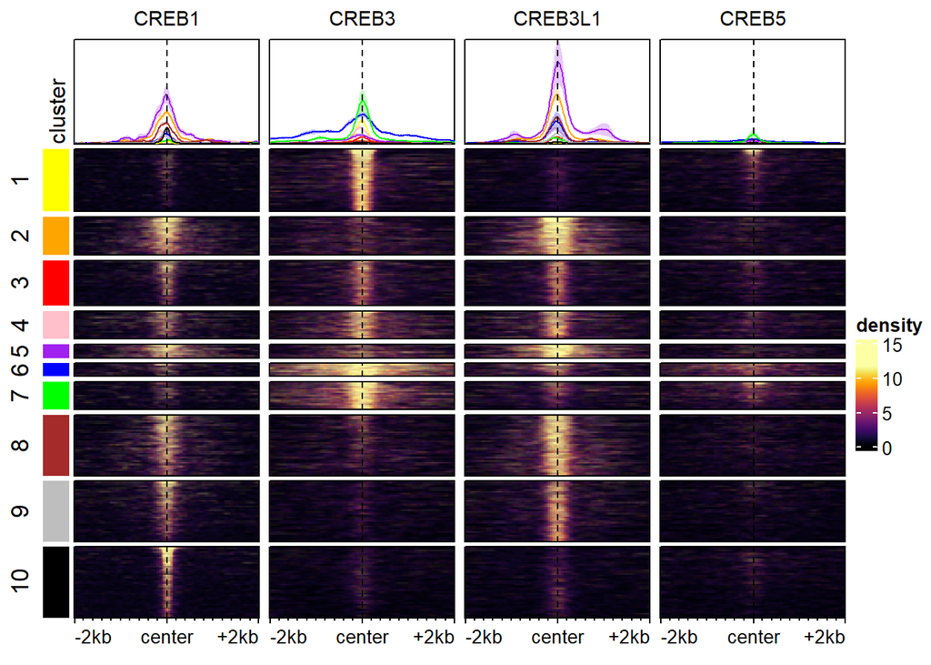

```r
# create a vector of colors and have as names of the vector the names of our clusters (in this case just numbers).
mycolors <- c("1"="yellow", "2"="orange", "3"="red", "4"="pink", "5"="purple", "6"="blue", "7"="green", "8"="brown", "9"="gray", "10"="black")
plotEnrichedHeatmaps(m_creb1, row_split=cl, mean_color=mycolors, trim=c(0.95))
```

Figure 4.3: A heatmap of the CREB family members split into 10 clusters, with assigned colors.

Generally said, CREB1 and CREB3L1 have rather narrow peaks and CREB3 tends to be more broad. CREB5 is not very present.

## Plotting just the averages

We tried to extract the average signals to get a more broad overview of the signals, we can also do this by cluster. This gives us a data frame that has for each cluster for each sample or signal at each position the value of the mean signal. We can use this to create a plot that tells us in each cluster what the average signals of each factor around the positions around the regions of interest are.

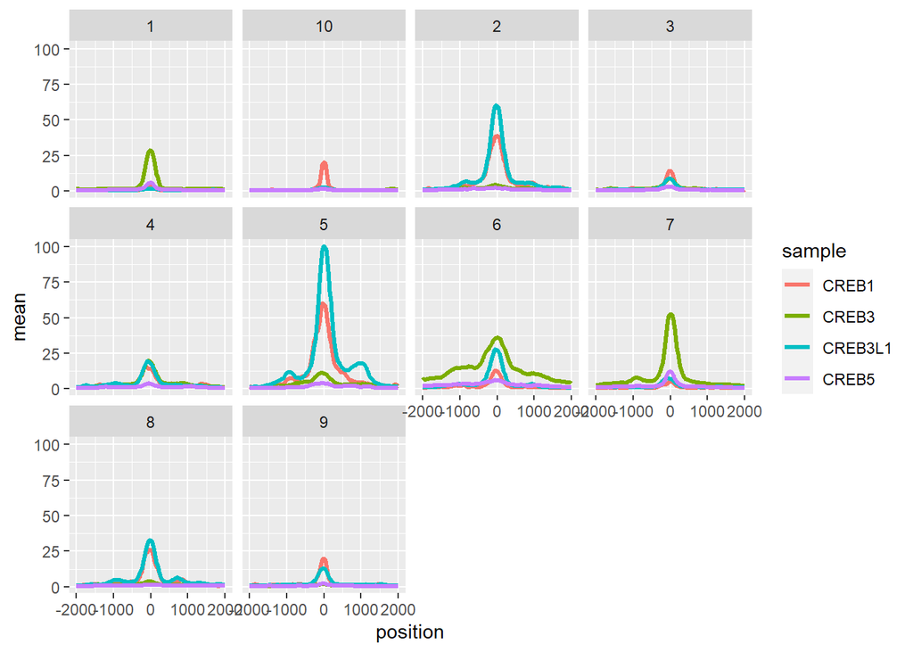

```r
d <- meltSignals(m_creb1, splitBy=cl)
ggplot(d, aes(position, mean, colour=sample)) + geom_line(size=1.2) + facet_wrap(~split)
```

Figure 4.4: Plot of the average signals of the CREB family members split by clusters.

These plots are exactly like the plots above the heat maps with the difference that instead of plotting the different lines for one signal together we are plotting the lines for one cluster but different signals together. You can plot whatever you want.

Clustering is dangerous because you might change around factors until you like the result.

From this plot we can generally tell once more that CREB5 is not very strongly involved in any of these peaks. All the other family members have some clusters where they are the strongest representative which means they might be strongly involved in whatever these processes represent.

# Enrichment analysis

Now we want to figure out what the regions are. For example what are the regions in cluster 2, are they associated with or close to genes that have a different kind of function than the regions in cluster 7? Typically you add more signals in order to find more patterns of correlation. Are they bound by other factors?

Find what’s enriched in one cluster with respect to the others (first we use cluster 2):

```r
# we first split the regions by cluster:
split_regions <- split(merged_peaks, cl)
# Important: when a job is submitted to GREAT a set of regions, a GRanges object, needs to be submitted BUT there also needs to be some sort of background added to the picture. The elements in a list of regions are always compared to other elements. So we are comparing the regions in cluster 2 with respect to all our other regions.
# sending the data to the server
job_2 <- submitGreatJob(split_regions[["2"]], merged_peaks, species="hg38")
#Human GRCh38/hg38 is the genome we used
job_2
```

```
## Submit time: 2022-07-09 10:48:46
## Version: 4.0.4
## Species: hg38
## Inputs: 303 regions
## Background: user-defined, 3330 regions
## Model: Basal plus extension
##   Proximal: 5 kb upstream, 1 kb downstream,
##   plus Distal: up to 1000 kb
## Include curated regulatory domains
##
## Enrichment tables for following ontologies have been downloaded:
##   None
```

```r
# we fetch the data back
res_2 <- getEnrichmentTables(job_2)
```

```
## The default enrichment tables contain no associated genes for the input
## regions. You can set `download_by = 'tsv'` to download the complete
## table, but note only the top 500 regions can be retreived. See the
## following link:
##
## https://great-help.atlassian.net/wiki/spaces/GREAT/pages/655401/Export#Export-GlobalExport
```

```r
names(res_2)
```

```
## [1] "GO Molecular Function" "GO Biological Process" "GO Cellular Component"
```

Molecular function is about being enzymes, signalling proteins, biological process is what they are involved in and cellular component is where they work. This gives us an overview.

## Plotting the top Biological Processes, molecular functions and cellular components of Cluster 2

```r
# looking at the biological processes
bp <- res_2$`GO Biological Process`
head(bp)
```

```
##           ID                                                      name
## 1 GO:0016241                              regulation of macroautophagy
## 2 GO:0000082                     G1/S transition of mitotic cell cycle
## 3 GO:0044843                          cell cycle G1/S phase transition
## 4 GO:0007339                        binding of sperm to zona pellucida
## 5 GO:0033629 negative regulation of cell adhesion mediated by integrin
## 6 GO:0035066                positive regulation of histone acetylation
##   Hyper_Total_Regions Hyper_Expected Hyper_Foreground_Region_Hits
## 1                  57       5.186486                           15
## 2                  44       4.003604                           12
## 3                  44       4.003604                           12
## 4                   3       0.272973                            3
## 5                   3       0.272973                            3
## 6                   3       0.272973                            3
##   Hyper_Fold_Enrichment Hyper_Region_Set_Coverage Hyper_Term_Region_Coverage
```

[output cut: 20 more lines]

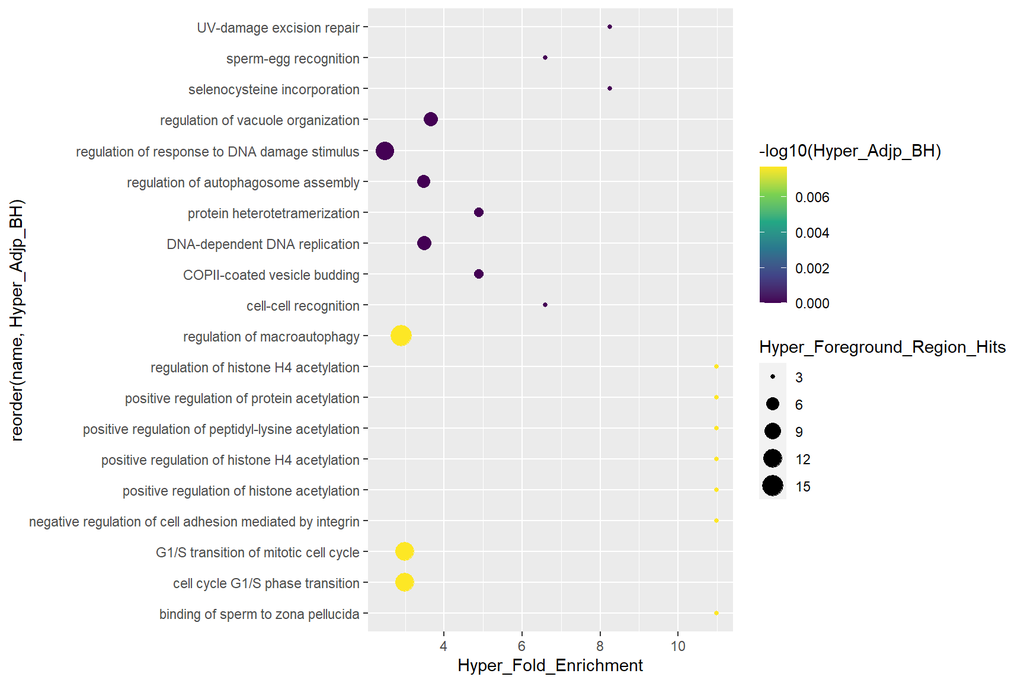

```r
# reorder it from most to least statistically significant before being alphabetically ordered.
ggplot(head(bp,20), aes(Hyper_Fold_Enrichment, reorder(name, Hyper_Adjp_BH), size=Hyper_Foreground_Region_Hits, color=-log10(Hyper_Adjp_BH))) + geom_point() + scale_color_viridis_c()
```

```r
# looking at the molecular function
mf <- res_2$`GO Molecular Function`
head(mf)
```

```
##           ID                                           name Hyper_Total_Regions
## 1 GO:0005087 Ran guanyl-nucleotide exchange factor activity                   8
## 2 GO:0031492                        nucleosomal DNA binding                  42
## 3 GO:0003723                                    RNA binding                 487
## 4 GO:0017112 Rab guanyl-nucleotide exchange factor activity                  13
## 5 GO:0045505              dynein intermediate chain binding                   5
## 6 GO:0031490                          chromatin DNA binding                  54
##   Hyper_Expected Hyper_Foreground_Region_Hits Hyper_Fold_Enrichment
## 1      0.7279279                            4              5.495050
## 2      3.8216220                           10              2.616690
## 3     44.3126100                           61              1.376583
## 4      1.1828830                            5              4.226961
## 5      0.4549550                            3              6.594059
## 6      4.9135140                           11              2.238724
##   Hyper_Region_Set_Coverage Hyper_Term_Region_Coverage
```

[output cut: 20 more lines]

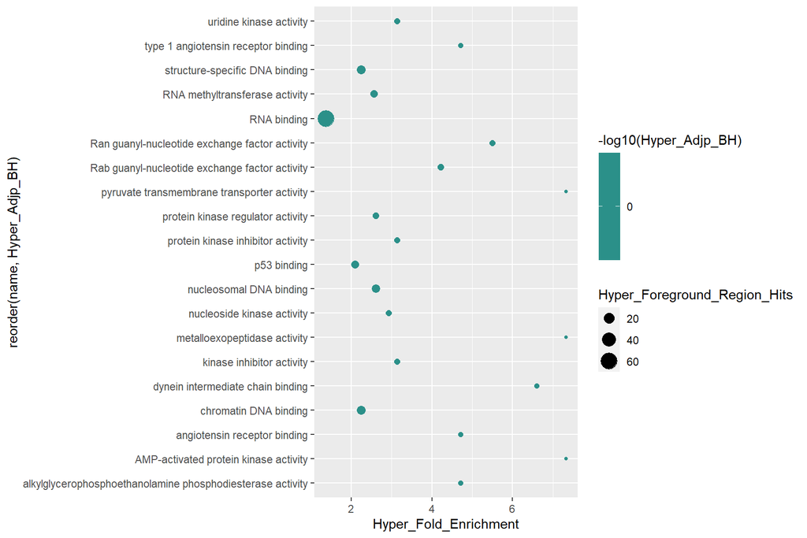

```r
ggplot(head(mf,20), aes(Hyper_Fold_Enrichment, reorder(name, Hyper_Adjp_BH), size=Hyper_Foreground_Region_Hits, color=-log10(Hyper_Adjp_BH))) + geom_point() + scale_color_viridis_c()
```

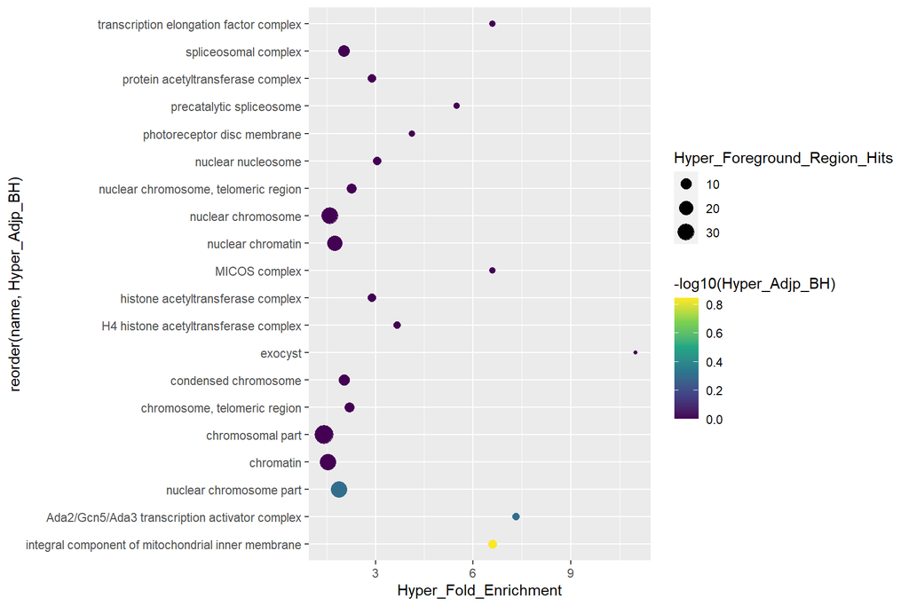

```r
# looking at cellular components
cc <- res_2$`GO Cellular Component`
ggplot(head(cc,20), aes(Hyper_Fold_Enrichment, reorder(name, Hyper_Adjp_BH), size=Hyper_Foreground_Region_Hits, color=-log10(Hyper_Adjp_BH))) + geom_point() + scale_color_viridis_c()
```

Figure 4.5a: Plot of the top biological processes of cluster 2. Figure 4.5b: Plot of the top molecular functions of cluster 2. Figure 4.5c: Plot of the top cellular components of cluster 2.

We get different genotology terms and it is telling us how many regions in our background are associated with this term and how many regions in our foreground, so the genes of interest are associated with this. Fold Enrichment is how much more we have in our region of interest than in the background.

On the x-axis is the strength of enrichment and the color of the dot represents its significance. Smaller sets need more enrichment in order to be significant than large sets. That’s why we look at both the significance and the fold enrichment which indicates the magnitude of enrichment.

Disclaimer: not everything makes sense because the same genes get reused in many biological processes, but we can learn something about what the clusters do.

### Do another Cluster - Cluster 9

Now we do the same analysis for cluster 9.

```r
job_9 <- submitGreatJob(split_regions[["9"]], merged_peaks, species="hg38")
```

```
## Don't make too frequent requests. The time break is 60s.
## Please wait for 49s for the next request.
## The time break can be set by `request_interval` argument.
```

```r
#Human GRCh38/hg38 is the genome we used
job_9
```

```
## Submit time: 2022-07-09 10:49:51
## Version: 4.0.4
## Species: hg38
## Inputs: 478 regions
## Background: user-defined, 3330 regions
## Model: Basal plus extension
##   Proximal: 5 kb upstream, 1 kb downstream,
##   plus Distal: up to 1000 kb
## Include curated regulatory domains
##
## Enrichment tables for following ontologies have been downloaded:
##   None
```

```r
# we fetch the data back
res_9 <- getEnrichmentTables(job_9)
```

```
## The default enrichment tables contain no associated genes for the input
## regions. You can set `download_by = 'tsv'` to download the complete
## table, but note only the top 500 regions can be retreived. See the
## following link:
##
## https://great-help.atlassian.net/wiki/spaces/GREAT/pages/655401/Export#Export-GlobalExport
```

```r
names(res_9)
```

```
## [1] "GO Molecular Function" "GO Biological Process" "GO Cellular Component"
```

## Plotting the top Biological Processes, molecular functions and cellular components of Cluster 9

```r
# looking at the biological processes
bp <- res_9$`GO Biological Process`
head(bp)
```

```
##           ID                                               name
## 1 GO:0035735 intraciliary transport involved in cilium assembly
## 2 GO:0042073                             intraciliary transport
## 3 GO:0098840                protein transport along microtubule
## 4 GO:0010970                        transport along microtubule
## 5 GO:0050807                 regulation of synapse organization
## 6 GO:0016055                              Wnt signaling pathway
##   Hyper_Total_Regions Hyper_Expected Hyper_Foreground_Region_Hits
## 1                  12       1.722523                            8
## 2                  12       1.722523                            8
## 3                  12       1.722523                            8
## 4                  33       4.736937                           14
## 5                  32       4.593393                           13
## 6                  91      13.062460                           26
##   Hyper_Fold_Enrichment Hyper_Region_Set_Coverage Hyper_Term_Region_Coverage
```

[output cut: 20 more lines]

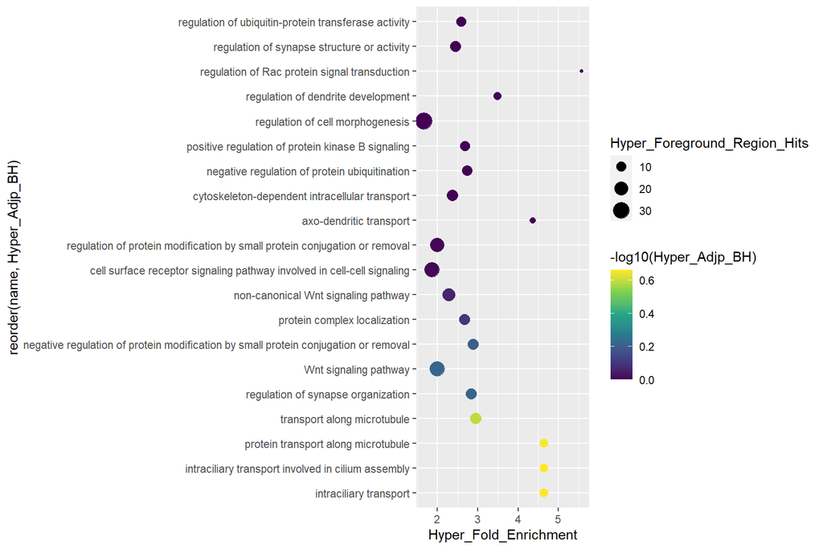

```r
# reorder it from most to least statistically significant before being alphabetically ordered.
ggplot(head(bp,20), aes(Hyper_Fold_Enrichment, reorder(name, Hyper_Adjp_BH), size=Hyper_Foreground_Region_Hits, color=-log10(Hyper_Adjp_BH))) + geom_point() + scale_color_viridis_c()
```

```r
# looking at the molecular function
mf <- res_9$`GO Molecular Function`
head(mf)
```

```
##           ID                                             name
## 1 GO:0004822                  isoleucine-tRNA ligase activity
## 2 GO:0055106 ubiquitin-protein transferase regulator activity
## 3 GO:0003755     peptidyl-prolyl cis-trans isomerase activity
## 4 GO:0016859                     cis-trans isomerase activity
## 5 GO:0002161                  aminoacyl-tRNA editing activity
## 6 GO:0004029            aldehyde dehydrogenase (NAD) activity
##   Hyper_Total_Regions Hyper_Expected Hyper_Foreground_Region_Hits
## 1                   3      0.4306306                            3
## 2                  10      1.4354350                            5
## 3                  27      3.8756760                            9
## 4                  27      3.8756760                            9
## 5                   4      0.5741742                            3
## 6                   4      0.5741742                            3
##   Hyper_Fold_Enrichment Hyper_Region_Set_Coverage Hyper_Term_Region_Coverage
```

[output cut: 20 more lines]

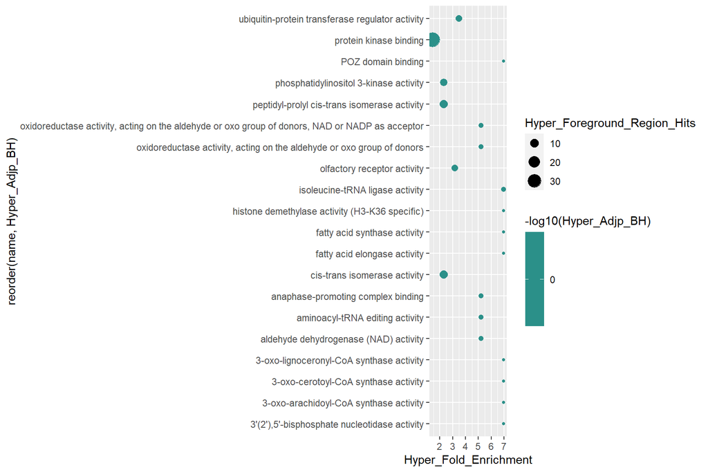

```r
ggplot(head(mf,20), aes(Hyper_Fold_Enrichment, reorder(name, Hyper_Adjp_BH), size=Hyper_Foreground_Region_Hits, color=-log10(Hyper_Adjp_BH))) + geom_point() + scale_color_viridis_c()
```

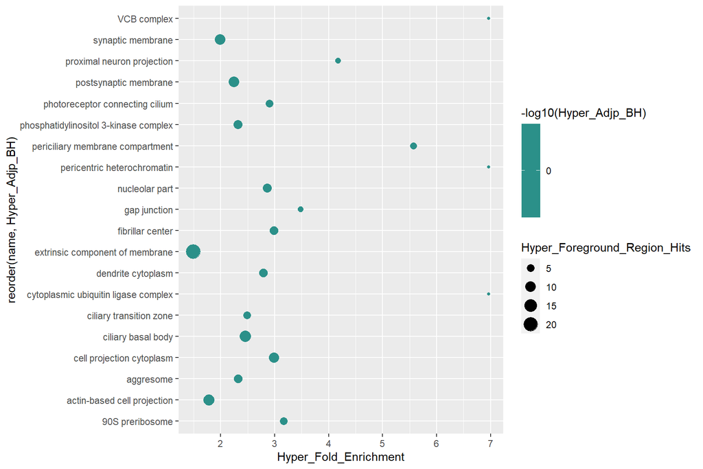

```r
# looking at cellular components
cc <- res_9$`GO Cellular Component`
ggplot(head(cc,20), aes(Hyper_Fold_Enrichment, reorder(name, Hyper_Adjp_BH), size=Hyper_Foreground_Region_Hits, color=-log10(Hyper_Adjp_BH))) + geom_point() + scale_color_viridis_c()
```

Figure 4.6a: Plot of the top biological processes of cluster 9. Figure 4.6b: Plot of the top molecular functions of cluster 9. Figure 4.6c: Plot of the top cellular components of cluster 9.

### Do another Cluster - Cluster 7

Now we do the same analysis for cluster 7.

```r
job_7 <- submitGreatJob(split_regions[["7"]], merged_peaks, species="hg38")
```

```
## Don't make too frequent requests. The time break is 60s.
## Please wait for 51s for the next request.
## The time break can be set by `request_interval` argument.
```

```r
#Human GRCh38/hg38 is the genome we used
job_7
```

```
## Submit time: 2022-07-09 10:50:57
## Version: 4.0.4
## Species: hg38
## Inputs: 220 regions
## Background: user-defined, 3330 regions
## Model: Basal plus extension
##   Proximal: 5 kb upstream, 1 kb downstream,
##   plus Distal: up to 1000 kb
## Include curated regulatory domains
##
## Enrichment tables for following ontologies have been downloaded:
##   None
```

```r
# we fetch the data back
res_7 <- getEnrichmentTables(job_7)
```

```
## The default enrichment tables contain no associated genes for the input
## regions. You can set `download_by = 'tsv'` to download the complete
## table, but note only the top 500 regions can be retreived. See the
## following link:
##
## https://great-help.atlassian.net/wiki/spaces/GREAT/pages/655401/Export#Export-GlobalExport
```

```r
names(res_7)
```

```
## [1] "GO Molecular Function" "GO Biological Process" "GO Cellular Component"
```

## Plotting the top Biological Processes, molecular functions and cellular components of Cluster 7

```r
# looking at the biological processes
bp <- res_7$`GO Biological Process`
head(bp)
```

```
##           ID                                          name Hyper_Total_Regions
## 1 GO:0009064 glutamine family amino acid metabolic process                  35
## 2 GO:0050896                          response to stimulus                1991
## 3 GO:1901605            alpha-amino acid metabolic process                 107
## 4 GO:0042110                             T cell activation                  74
## 5 GO:0071593                        lymphocyte aggregation                  74
## 6 GO:0007159                  leukocyte cell-cell adhesion                  75
##   Hyper_Expected Hyper_Foreground_Region_Hits Hyper_Fold_Enrichment
## 1       2.312312                           12              5.189610
## 2     131.537500                          161              1.223985
## 3       7.069069                           20              2.829227
## 4       4.888889                           16              3.272727
## 5       4.888889                           16              3.272727
## 6       4.954955                           16              3.229091
##   Hyper_Region_Set_Coverage Hyper_Term_Region_Coverage
```

[output cut: 20 more lines]

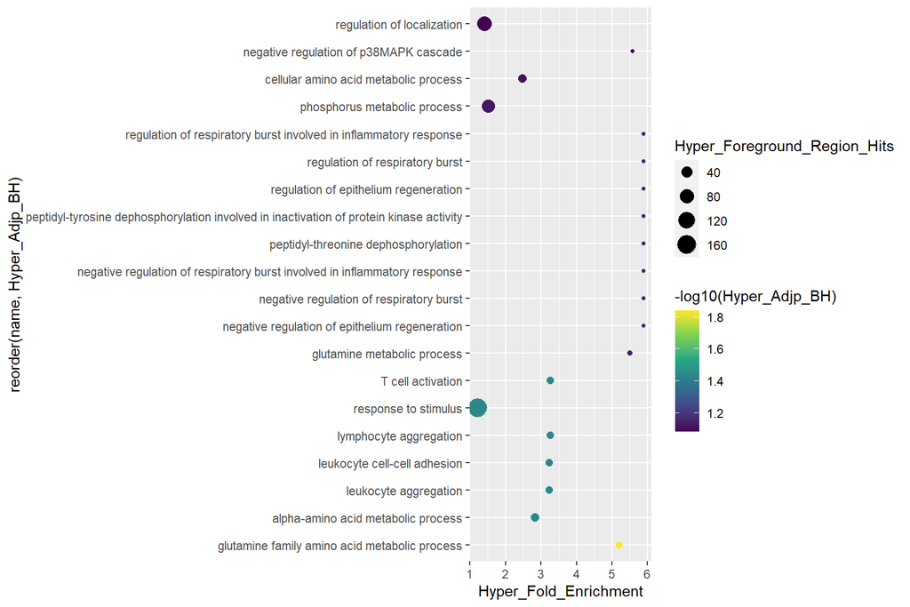

```r
# reorder it from most to least statistically significant before being alphabetically ordered.
ggplot(head(bp,20), aes(Hyper_Fold_Enrichment, reorder(name, Hyper_Adjp_BH), size=Hyper_Foreground_Region_Hits, color=-log10(Hyper_Adjp_BH))) + geom_point() + scale_color_viridis_c()
```

```r
# looking at the molecular function
mf <- res_7$`GO Molecular Function`
head(mf)
```

```
##           ID
## 1 GO:0001191
## 2 GO:0017017
## 3 GO:0033549
## 4 GO:0048273
## 5 GO:0004721
## 6 GO:0000988
##                                                                                 name
## 1 transcriptional repressor activity, RNA polymerase II transcription factor binding
## 2                          MAP kinase tyrosine/serine/threonine phosphatase activity
## 3                                                    MAP kinase phosphatase activity
## 4                                       mitogen-activated protein kinase p38 binding
## 5                                                phosphoprotein phosphatase activity
## 6                                     transcription factor activity, protein binding
##   Hyper_Total_Regions Hyper_Expected Hyper_Foreground_Region_Hits
```

[output cut: 27 more lines]

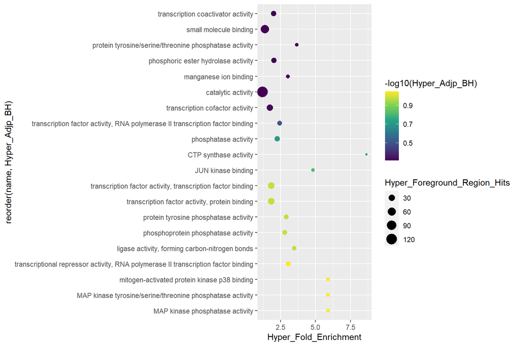

```r
ggplot(head(mf,20), aes(Hyper_Fold_Enrichment, reorder(name, Hyper_Adjp_BH), size=Hyper_Foreground_Region_Hits, color=-log10(Hyper_Adjp_BH))) + geom_point() + scale_color_viridis_c()
```

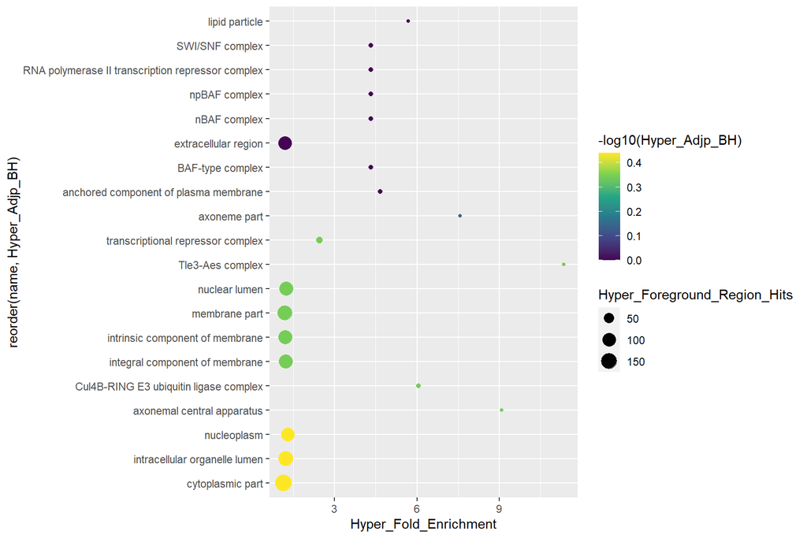

```r
# looking at cellular components
cc <- res_7$`GO Cellular Component`
ggplot(head(cc,20), aes(Hyper_Fold_Enrichment, reorder(name, Hyper_Adjp_BH), size=Hyper_Foreground_Region_Hits, color=-log10(Hyper_Adjp_BH))) + geom_point() + scale_color_viridis_c()
```

Figure 4.7a: Plot of the top biological processes of cluster 7. Figure 4.7b: Plot of the top molecular functions of cluster 7. Figure 4.7c: Plot of the top cellular components of cluster 7.

All the results above are to be enjoyed with caution and will be further evaluated and compared with existing knowledge about the different CREB family members in our discussion and conclusion section.